# Practical Machine Learning - Barbell Lift Form Data

Dataset information is available here: http://groupware.les.inf.puc-rio.br/har#dataset

Participants were asked to lift a barbell in one of five ways:

- Class A: Perfect form
- Class B: Throwing elbows to the front
- Class C: Lifting the dumbbell only halfway
- Class D: Lowering the dumbbell only halfway
- Class E: Throwing the hips forward

These categories are included in the *classe* variable. Each participant had several sensors attached to his or her body, producing quite a large number of predictor variables. The goal of this project is to use these predictor variables to determine the class of lift.

```r
#library(knitr)
library(caret)
library(ggplot2)

orig_train <- read.csv('pml-training.csv', header=TRUE, na.strings = c("", " ", "#DIV/0!", "NA"))
orig_test <- read.csv('pml-testing.csv', header=TRUE, na.strings = c("", " ", "#DIV/0!", "NA"))
```

Next we will split the training set into training and testing subsets. We will use this new test set to cross-validate and get an estimate of how well our model is doing.

```r
set.seed(22012015)
inTrain <- createDataPartition(y=orig_train$classe, p=0.6, list=FALSE)

training <- orig_train[inTrain,]
testing <- orig_train[-inTrain,]
```

## Data Processing

We have a very large number of variables here. Let’s start by checking how many NA values are under each variable.

```r
allVars <- names(training[8:153])

countNA <- sapply(1:length(allVars), function(x) sum(is.na(training[allVars[x]])))
names(countNA) <- allVars

head(countNA)
```

```
##           roll_belt          pitch_belt            yaw_belt
##                   0                   0                   0
##    total_accel_belt  kurtosis_roll_belt kurtosis_picth_belt
##                   0               11533               11541
```

We can see that some of the variables have complete data, and others have almost no data. We will take out the variables that do not have enough data to be useful.

```r
cleanVars <- c(allVars[countNA == 0], "classe")
trainClean <- training[cleanVars]
```

## Decision Tree

The first method that we will try is a decision tree. We can use the *caret* package to fit this model.

```r
treeFit <- train(classe~., method="rpart", data=trainClean)
print(treeFit$finalModel)
```

```
## n= 11776
##
## node), split, n, loss, yval, (yprob)
##       * denotes terminal node
##
##  1) root 11776 8428 A (0.28 0.19 0.17 0.16 0.18)
##    2) roll_belt< 130.5 10790 7450 A (0.31 0.21 0.19 0.18 0.11)
##      4) pitch_forearm< -34.6 920    1 A (1 0.0011 0 0 0) *
##      5) pitch_forearm>=-34.6 9870 7449 A (0.25 0.23 0.21 0.2 0.12)
##       10) magnet_dumbbell_y< 439.5 8342 5973 A (0.28 0.18 0.24 0.19 0.11)
##         20) roll_forearm< 120.5 5171 3043 A (0.41 0.18 0.18 0.16 0.064) *
##         21) roll_forearm>=120.5 3171 2128 C (0.076 0.18 0.33 0.24 0.18) *
##       11) magnet_dumbbell_y>=439.5 1528  747 B (0.034 0.51 0.042 0.23 0.19) *
##    3) roll_belt>=130.5 986    8 E (0.0081 0 0 0 0.99) *
```

```r
prediction <- predict(treeFit, newdata=testing)
```

A confusion matrix will let us know how accurate our predictions were on the testing sub-set.

```r
library(mda)
confusion(prediction, testing$classe)
```

```
##          true
## predicted    A   B   C   D   E
##         A 2011 595 636 578 193
##         B   29 505  44 222 201
##         C  186 418 688 486 395
##         D    0   0   0   0   0
##         E    6   0   0   0 653
## attr(,"error")
## [1] 0.5084
```

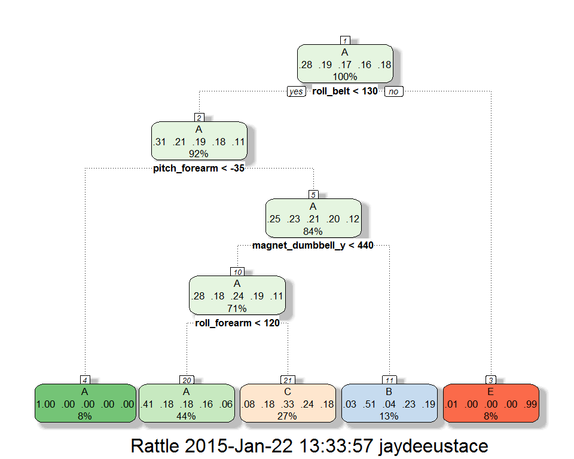

```r
library(rattle)
fancyRpartPlot(treeFit$finalModel)
```

## Random Forest

A random forest is a large collection of decision trees, and is usually much more accurate than a single tree. We will use *randomForest* instead of *train()* as it is more efficient

```r
library(randomForest)
forestFit <- randomForest(classe~., data=trainClean, importance=TRUE, ntree=5)
forestFit
```

```
##
## Call:
##  randomForest(formula = classe ~ ., data = trainClean, importance = TRUE,      ntree = 5)
##                Type of random forest: classification
##                      Number of trees: 5
## No. of variables tried at each split: 6
##
##         OOB estimate of  error rate: 8.11%
## Confusion matrix:
##      A    B    C    D    E class.error
## A 2900   47   24   36   16     0.04069
## B   82 1800   85   46   36     0.12152
## C   22   95 1645   54   34     0.11081
## D   30   40   65 1582   18     0.08818
## E   15   41   38   34 1798     0.06646
```

```r
prediction2 <- predict(forestFit, newdata=testing)
```

### Out of Sample Error and Importance

```r
confusion(prediction2, testing$classe)
```

```
##          true
## predicted    A    B    C    D    E
##         A 2216   21    7    2    1
##         B   11 1462   38    9    4
##         C    1   26 1290   19   10
##         D    3    5   29 1255    4
##         E    1    4    4    1 1423
## attr(,"error")
## [1] 0.02549
```

After producing a confusion matrix, we conclude that the out of sample error should be about 2.55% with this random forest method.

```r
head(importance(forestFit), n=5)
```

```
##                      A     B      C     D     E MeanDecreaseAccuracy
## roll_belt        2.993 4.206  4.171 5.383 4.090                4.470
## pitch_belt       2.894 3.646  8.513 3.171 3.509                4.047
## yaw_belt         7.723 3.182 15.457 4.664 6.238                9.278
## total_accel_belt 2.883 3.173  2.501 2.572 3.184                3.389
## gyros_belt_x     1.945 1.574  3.501 4.244 2.617                2.925
##                  MeanDecreaseGini
## roll_belt                  725.47
## pitch_belt                 494.44
## yaw_belt                   631.93
## total_accel_belt           107.03
## gyros_belt_x                67.38
```

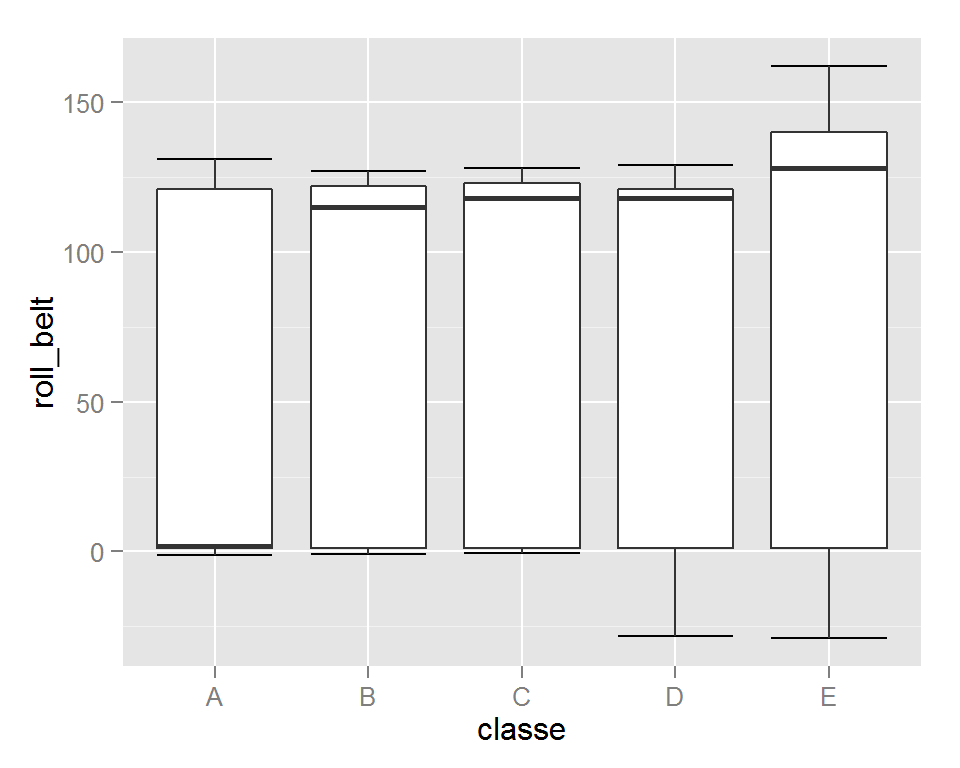

```r
ggplot(trainClean, aes(x=classe, y = roll_belt))  + stat_boxplot(geom ='errorbar') + geom_boxplot()
```

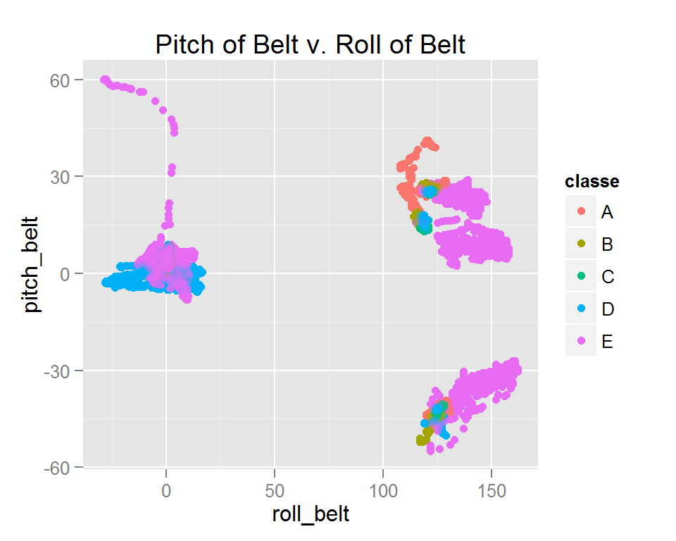

```r
with(trainClean, qplot(roll_belt, pitch_belt, col=classe, main='Pitch of Belt v. Roll of Belt') + geom_point(alpha = 1/10))
```

## Random Forest on Test Set

Finally, we should use a random forest to predict the test set.

```r
predictionFinal <- predict(forestFit, newdata=orig_test)
predictionFinal
```

```
##  1  2  3  4  5  6  7  8  9 10 11 12 13 14 15 16 17 18 19 20
##  B  A  B  A  A  C  D  D  A  A  B  C  B  A  E  E  A  B  B  B
## Levels: A B C D E
```

```r
pml_write_files = function(x){
  n = length(x)
  for(i in 1:n){
    filename = paste0("problem_id_",i,".txt")
    write.table(x[i],file=filename,quote=FALSE,row.names=FALSE,col.names=FALSE)
  }
}

pml_write_files(as.character(predictionFinal))
```

On the final test set, this method got a score of 18/20.